# Customer Sentiment Across All Businesses On Yelp

Predrag Tomovic

2025-02-06

## Abstract

This project performs exploratory data analysis (EDA) on ~10,000 Yelp reviews sourced from Kaggle. The goal is to analyze sentiment trends across businesses in various industries, including restaurants, retail, and services. Using lexicon-based sentiment analysis and tools like R, dplyr, and ggplot2, the analysis focuses on:

Overall sentiment trends across industries. Common themes and emotional tones in customer feedback. Relationships between review characteristics (e.g., word count) and sentiment scores. The results provide actionable insights into customer sentiment, helping businesses identify strengths and areas for improvement.

## Preparation

### Loading Packages and Data

The analysis relies on several R packages to facilitate data processing, sentiment analysis, and visualization. Below is a list of the core packages used:

```r
library(dplyr)      # For data manipulation and aggregation.
library(tidytext)   # To tokenize text and process sentiment lexicons.
library(ggplot2)    # For creating visualizations of sentiment trends and relationships.
library(lubridate)  # To handle date-related operations (e.g., grouping by month).
library(stringr)    # For text cleaning and string manipulation.
library(tidyr)      # To reshape and organize data for analysis.
library(readr)      # For reading and loading dataset files.
library(sentimentr) # To implement VADER sentiment scoring.
library(syuzhet)    # For sentiment analysis using NRC and Bing lexicons.
```

Loading data:

```r
yelp_raw <- readr::read_csv("~/R practice/Yelp Text Sentiment Analysis/yelp.csv") # Yelp dataset: 10,000 restaurant reviews with columns for text, stars, date, etc.
```

Exploring data structure of yelp_raw:

```
## spc_tbl_ [10,000 × 10] (S3: spec_tbl_df/tbl_df/tbl/data.frame)
##  $ business_id: chr [1:10000] "9yKzy9PApeiPPOUJEtnvkg" "ZRJwVLyzEJq1VAihDhYiow" "6oRAC4uyJCsJl1X0WZpVSA" "_1QQZuf4zZOyFCvXc0o6Vg" ...
##  $ date       : Date[1:10000], format: "2011-01-26" "2011-07-27" ...
##  $ review_id  : chr [1:10000] "fWKvX83p0-ka4JS3dc6E5A" "IjZ33sJrzXqU-0X6U8NwyA" "IESLBzqUCLdSzSqm0eCSxQ" "G-WvGaISbqqaMHlNnByodA" ...
##  $ stars      : num [1:10000] 5 5 4 5 5 4 5 4 4 5 ...
##  $ text       : chr [1:10000] "My wife took me here on my birthday for breakfast and it was excellent.  The weather was perfect which made sit"| __truncated__ "I have no idea why some people give bad reviews about this place. It goes to show you, you can please everyone."| __truncated__ "love the…
##  $ type       : chr [1:10000] "review" "review" "review" "review" ...
##  $ user_id    : chr [1:10000] "rLtl8ZkDX5vH5nAx9C3q5Q" "0a2KyEL0d3Yb1V6aivbIuQ" "0hT2KtfLiobPvh6cDC8JQg" "uZetl9T0NcROGOyFfughhg" ...
##  $ cool       : num [1:10000] 2 0 0 1 0 4 7 0 0 0 ...
##  $ useful     : num [1:10000] 5 0 1 2 0 3 7 1 0 1 ...
##  $ funny      : num [1:10000] 0 0 0 0 0 1 4 0 0 0 ...
##  - attr(*, "spec")=
##   .. cols(
##   ..   business_id = col_character(),
##   ..   date = col_date(format = ""),
##   ..   review_id = col_character(),
##   ..   stars = col_double(),
##   ..   text = col_character(),
##   ..   type = col_character(),
##   ..   user_id = col_character(),
##   ..   cool = col_double(),
##   ..   useful = col_double(),
##   ..   funny = col_double()
##   .. )
##  - attr(*, "problems")=<externalptr>
```

Summary of yelp_raw:

```
##  business_id             date             review_id             stars
##  Length:10000       Min.   :2005-04-18   Length:10000       Min.   :1.000
##  Class :character   1st Qu.:2010-02-15   Class :character   1st Qu.:3.000
##  Mode  :character   Median :2011-04-17   Mode  :character   Median :4.000
##                     Mean   :2011-01-04                      Mean   :3.777
##                     3rd Qu.:2012-03-07                      3rd Qu.:5.000
##                     Max.   :2013-01-05                      Max.   :5.000
##      text               type             user_id               cool
##  Length:10000       Length:10000       Length:10000       Min.   : 0.0000
##  Class :character   Class :character   Class :character   1st Qu.: 0.0000
##  Mode  :character   Mode  :character   Mode  :character   Median : 0.0000
##                                                           Mean   : 0.8768
##                                                           3rd Qu.: 1.0000
##                                                           Max.   :77.0000
##      useful           funny
##  Min.   : 0.000   Min.   : 0.0000
##  1st Qu.: 0.000   1st Qu.: 0.0000
##  Median : 1.000   Median : 0.0000
##  Mean   : 1.409   Mean   : 0.7013
##  3rd Qu.: 2.000   3rd Qu.: 1.0000
##  Max.   :76.000   Max.   :57.0000
```

Checking for missing values:

```
## [1] "Are there missing values?"
```

```
## business_id        date   review_id       stars        text        type
##           0           0           0           0           0           0
##     user_id        cool      useful       funny
##           0           0           0           0
```

To streamline the analysis, we filter the dataset to include only relevant columns: review_id, user_id, text, date, stars, and business_id.

```r
# Filter dataset to include only necessary columns for sentiment analysis
yelp_text <- yelp_raw %>%
  select(review_id, user_id, text, date, stars, business_id)

# Inspect the filtered dataset
glimpse(yelp_text)
```

```
## Rows: 10,000
## Columns: 6
## $ review_id   <chr> "fWKvX83p0-ka4JS3dc6E5A", "IjZ33sJrzXqU-0X6U8NwyA", "IESLB…
## $ user_id     <chr> "rLtl8ZkDX5vH5nAx9C3q5Q", "0a2KyEL0d3Yb1V6aivbIuQ", "0hT2K…
## $ text        <chr> "My wife took me here on my birthday for breakfast and it …
## $ date        <date> 2011-01-26, 2011-07-27, 2012-06-14, 2010-05-27, 2012-01-0…
## $ stars       <dbl> 5, 5, 4, 5, 5, 4, 5, 4, 4, 5, 5, 5, 5, 4, 4, 2, 3, 5, 3, 4…
## $ business_id <chr> "9yKzy9PApeiPPOUJEtnvkg", "ZRJwVLyzEJq1VAihDhYiow", "6oRAC…
```

Checking if we lost any values after filtering:

```
##   review_id     user_id        text        date       stars business_id
##           0           0           0           0           0           0
```

### Pie chart of review distributions by stars

This pie chart illustrates the proportion of restaurant reviews by star rating, based on a Yelp dataset with total number of reviews being 10000.

```
## [1] 0
```

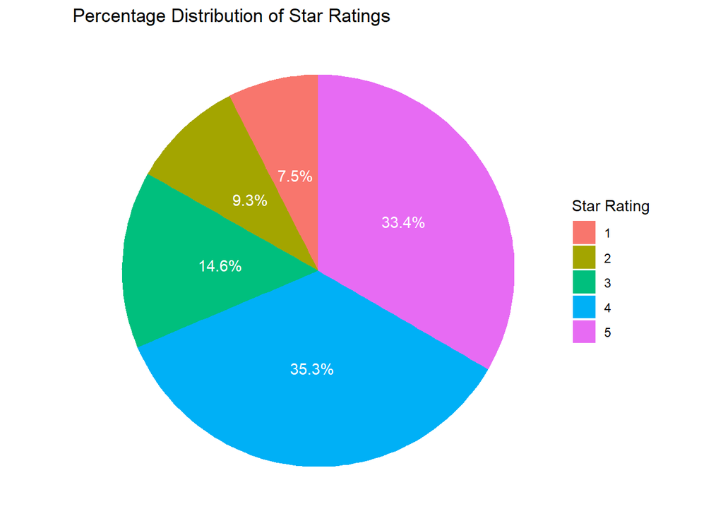

```r
# Analyze the distribution of star ratings to understand overall customer sentiment.

# Step 1: Calculate the percentage distribution of each star rating
reviews_by_star <- yelp_text %>%
  group_by(stars) %>%
  summarise(count = n()) %>%
  mutate(percentage = (count / sum(count)) * 100)  # Calculate percentage


# Step 2: Create the pie chart
ggplot(reviews_by_star, aes(x = "", y = percentage, fill = factor(stars))) +
  geom_bar(width = 1, stat = "identity") +
  coord_polar("y") +
  labs(
    title = "Percentage Distribution of Star Ratings",
    fill = "Star Rating"
  ) +
  theme_void() +  # Remove unnecessary background and axes
  geom_text(aes(label = paste0(round(percentage, 1), "%")),
            position = position_stack(vjust = 0.5),
            color = "white")  # Add percentage labels
```

To add a different view of the data the bar chart is added:

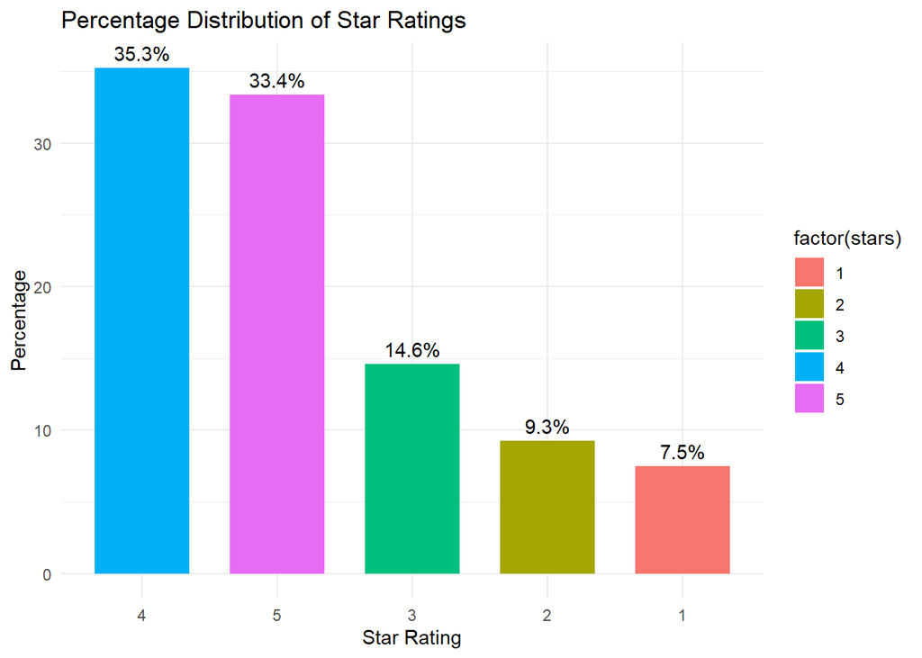

```r
# Additional visualization: bar chart
ggplot(reviews_by_star, aes(x = reorder(factor(stars), -percentage), y = percentage, fill = factor(stars))) +
  geom_bar(stat = "identity", width = 0.7) +
  labs(
    title = "Percentage Distribution of Star Ratings",
    x = "Star Rating",
    y = "Percentage"
  ) +
  theme_minimal() +
  geom_text(aes(label = paste0(round(percentage, 1), "%")),
            vjust = -0.5, color = "black")
```

The chart reveals a pronounced positive bias, with 68.7% of all reviews concentrated in the 4-star (35.3%) and 5-star (33.4%) categories. The remaining 31.3% of reviews are distributed across 1-star (7.49%), 2-star (9.27%), and 3-star (14.6%) ratings.

This reveals that most of the reviews are positive and that positive bias is to be expected with all further statistical analysis.

## Tokenization

Tokenization is the process of splitting text into individual words, or tokens, which allows us to analyze each word independently. In sentiment analysis, this step is critical, as it enables us to assign sentiment values to individual words and then aggregate those scores to understand the overall sentiment of each review.

In this step, we will:

Convert the text data into a tidy format. Tokenize each review into individual words. Remove common stop words, such as “and,” “the,” and “is,” as they do not contribute to sentiment and can be safely excluded.

```r
# Load stop words data
data("stop_words")

# adding custom stop words likely appearing in this dataset
custom_stop_words <- tibble(word = c("restaurant", "place", "order", "get", ".", " ", ""))
stop_words <- bind_rows(stop_words, custom_stop_words)

# Tokenize and clean the review text:
# - Split text into individual words.
# - Convert words to lowercase and remove numbers.
# - Remove common stop words to focus on meaningful terms.
# Tokenize and clean the review text
yelp_words <- yelp_text %>%
  unnest_tokens(word, text) %>%       # Tokenize: split text into individual words
  mutate(
    word = tolower(word),             # Convert all words to lowercase
    word = gsub("[^a-z]", "", word)   # Remove non-alphabetic characters
  ) %>%
  filter(word != "") %>%              # Remove empty values
  anti_join(stop_words, by = "word")  # Remove common stop words

# Inspect the cleaned, tokenized data
glimpse(yelp_words)
```

```
## Rows: 470,263
## Columns: 6
## $ review_id   <chr> "fWKvX83p0-ka4JS3dc6E5A", "fWKvX83p0-ka4JS3dc6E5A", "fWKvX…
## $ user_id     <chr> "rLtl8ZkDX5vH5nAx9C3q5Q", "rLtl8ZkDX5vH5nAx9C3q5Q", "rLtl8…
## $ date        <date> 2011-01-26, 2011-01-26, 2011-01-26, 2011-01-26, 2011-01-2…
## $ stars       <dbl> 5, 5, 5, 5, 5, 5, 5, 5, 5, 5, 5, 5, 5, 5, 5, 5, 5, 5, 5, 5…
## $ business_id <chr> "9yKzy9PApeiPPOUJEtnvkg", "9yKzy9PApeiPPOUJEtnvkg", "9yKzy…
## $ word        <chr> "wife", "birthday", "breakfast", "excellent", "weather", "…
```

**Explanation of Each Cleaning Step**

*tolower(word):* Converts all words to lowercase to ensure consistency (e.g., “Food” and “food” are treated as the same word).

*anti_join(stop_words, by = “word”):* Removes common stop words (e.g., “the”, “and”, “is”) that don’t add much meaning to the analysis

## Bing Lexicon Join

The Bing lexicon is a sentiment lexicon that categorizes words as either positive or negative. Using it helps us quickly assess overall sentiment trends in Yelp reviews by associating individual words with a binary sentiment classification.

In this step, we will:

Join the Bing lexicon with the tokenized yelp_words data to label each word as positive or negative. Summarize sentiment scores for each review by counting the frequency of positive and negative words. Explore the most common words associated with each sentiment to identify common themes and topics.

### Step 1: Join the Bing Lexicon with Tokenized Data

```r
# Assign sentiment labels to tokenized words using the Bing lexicon.
# - Positive/negative labels help identify sentiment trends in reviews.
# Note: Words not found in the Bing lexicon are assigned NA for sentiment.
# These words are excluded from the sentiment distribution visualization.

# Load the Bing lexicon for sentiment analysis
bing <- get_sentiments("bing")

# Join the tokenized Yelp words with the Bing sentiment lexicon
yelp_bing <- yelp_words %>%
  left_join(bing, by = "word")

# Take a look at the data after joining to see sentiment assignments
head(yelp_bing)
```

```
## # A tibble: 6 × 7
##   review_id              user_id    date       stars business_id word  sentiment
##   <chr>                  <chr>      <date>     <dbl> <chr>       <chr> <chr>
## 1 fWKvX83p0-ka4JS3dc6E5A rLtl8ZkDX… 2011-01-26     5 9yKzy9PApe… wife  <NA>
## 2 fWKvX83p0-ka4JS3dc6E5A rLtl8ZkDX… 2011-01-26     5 9yKzy9PApe… birt… <NA>
## 3 fWKvX83p0-ka4JS3dc6E5A rLtl8ZkDX… 2011-01-26     5 9yKzy9PApe… brea… <NA>
## 4 fWKvX83p0-ka4JS3dc6E5A rLtl8ZkDX… 2011-01-26     5 9yKzy9PApe… exce… positive
## 5 fWKvX83p0-ka4JS3dc6E5A rLtl8ZkDX… 2011-01-26     5 9yKzy9PApe… weat… <NA>
## 6 fWKvX83p0-ka4JS3dc6E5A rLtl8ZkDX… 2011-01-26     5 9yKzy9PApe… perf… positive
```

```r
glimpse(yelp_bing)
```

```
## Rows: 470,263
## Columns: 7
## $ review_id   <chr> "fWKvX83p0-ka4JS3dc6E5A", "fWKvX83p0-ka4JS3dc6E5A", "fWKvX…
## $ user_id     <chr> "rLtl8ZkDX5vH5nAx9C3q5Q", "rLtl8ZkDX5vH5nAx9C3q5Q", "rLtl8…
## $ date        <date> 2011-01-26, 2011-01-26, 2011-01-26, 2011-01-26, 2011-01-2…
## $ stars       <dbl> 5, 5, 5, 5, 5, 5, 5, 5, 5, 5, 5, 5, 5, 5, 5, 5, 5, 5, 5, 5…
## $ business_id <chr> "9yKzy9PApeiPPOUJEtnvkg", "9yKzy9PApeiPPOUJEtnvkg", "9yKzy…
## $ word        <chr> "wife", "birthday", "breakfast", "excellent", "weather", "…
## $ sentiment   <chr> NA, NA, NA, "positive", NA, "positive", NA, NA, NA, NA, "p…
```

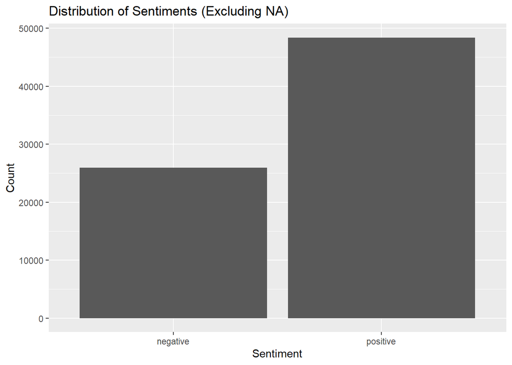

```r
# visualizing distribution of sentiments
ggplot(yelp_bing %>% filter(!is.na(sentiment)), aes(x = sentiment)) +
  geom_bar() +
  labs(title = "Distribution of Sentiments (Excluding NA)", x = "Sentiment", y = "Count")
```

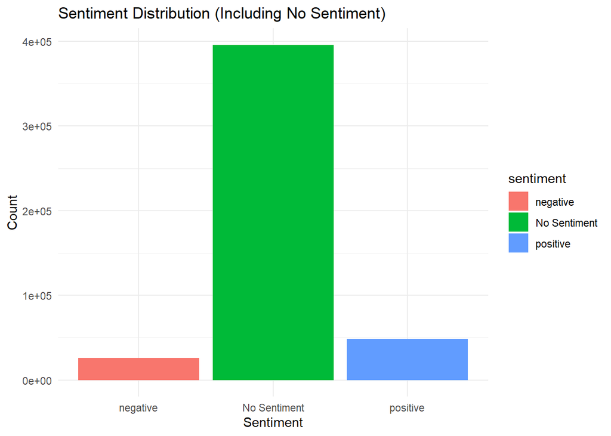

```r
# visualizing NA separatly
sentiment_summary <- yelp_bing %>%
  mutate(sentiment = ifelse(is.na(sentiment), "No Sentiment", sentiment)) %>%
  count(sentiment)

ggplot(sentiment_summary, aes(x = sentiment, y = n, fill = sentiment)) +
  geom_bar(stat = "identity") +
  labs(title = "Sentiment Distribution (Including No Sentiment)", x = "Sentiment", y = "Count") +
  theme_minimal()
```

Here it was noticed the vast difference in frequency of words with no sentiment value compared to the words with sentiment value. This bar chart had to be further explored and next code chunk will quantify what percentage of total words has sentiment value.

```r
# calculating percentage of words with sentiment labels
lexicon_coverage <- yelp_bing %>%
  summarise(
    total_words = n(),
    words_with_sentiment = sum(!is.na(sentiment)),
    coverage = words_with_sentiment / total_words * 100
  )
print(lexicon_coverage)
```

```
## # A tibble: 1 × 3
##   total_words words_with_sentiment coverage
##         <int>                <int>    <dbl>
## 1      470263                74311     15.8
```

Coverage value is very low (15.8%) following code chunk will merge AFINN, NRC and Bing lexicons and that will be the combined lexicon that will be used in attempt to increase coverage value.

```r
# Load the lexicons
afinn <- get_sentiments("afinn")
nrc <- get_sentiments("nrc")
bing <- get_sentiments("bing")

# Combine lexicons into one dataframe
combined_lexicon <- bind_rows(
  afinn %>% mutate(source = "afinn", sentiment = ifelse(value > 0, "positive", "negative")),
  nrc %>% filter(sentiment %in% c("positive", "joy", "trust", "negative", "sadness", "anger", "disgust", "fear")) %>% mutate(source = "nrc"),
  bing %>% mutate(source = "bing")
)

# View the combined lexicon
glimpse(combined_lexicon)
```

```
## Rows: 21,766
## Columns: 4
## $ word      <chr> "abandon", "abandoned", "abandons", "abducted", "abduction",…
## $ value     <dbl> -2, -2, -2, -2, -2, -2, -3, -3, -3, -3, 2, 2, 1, -1, -1, 2, …
## $ source    <chr> "afinn", "afinn", "afinn", "afinn", "afinn", "afinn", "afinn…
## $ sentiment <chr> "negative", "negative", "negative", "negative", "negative", …
```

Joining the combined lexicon with tokenized data

```r
# Join the tokenized Yelp words with the combined lexicon
yelp_combined <- yelp_words %>%
  left_join(combined_lexicon, by = "word")
# Inspect the resulting dataframe
head(yelp_combined)
```

```
## # A tibble: 6 × 9
##   review_id    user_id date       stars business_id word  value source sentiment
##   <chr>        <chr>   <date>     <dbl> <chr>       <chr> <dbl> <chr>  <chr>
## 1 fWKvX83p0-k… rLtl8Z… 2011-01-26     5 9yKzy9PApe… wife     NA <NA>   <NA>
## 2 fWKvX83p0-k… rLtl8Z… 2011-01-26     5 9yKzy9PApe… birt…    NA nrc    joy
## 3 fWKvX83p0-k… rLtl8Z… 2011-01-26     5 9yKzy9PApe… birt…    NA nrc    positive
## 4 fWKvX83p0-k… rLtl8Z… 2011-01-26     5 9yKzy9PApe… brea…    NA nrc    positive
## 5 fWKvX83p0-k… rLtl8Z… 2011-01-26     5 9yKzy9PApe… exce…     3 afinn  positive
## 6 fWKvX83p0-k… rLtl8Z… 2011-01-26     5 9yKzy9PApe… exce…    NA nrc    joy
```

calculating new coverage value

```r
# Calculate lexicon coverage
lexicon_coverage <- yelp_combined %>%
  summarise(
    total_words = n(),
    words_with_sentiment = sum(!is.na(sentiment)),
    coverage = words_with_sentiment / total_words * 100
  )

print(lexicon_coverage)
```

```
## # A tibble: 1 × 3
##   total_words words_with_sentiment coverage
##         <int>                <int>    <dbl>
## 1      678986               349854     51.5
```

### Visualizing the sentiment

Sentiment intensity (AFINN scores)

[figure not shown]

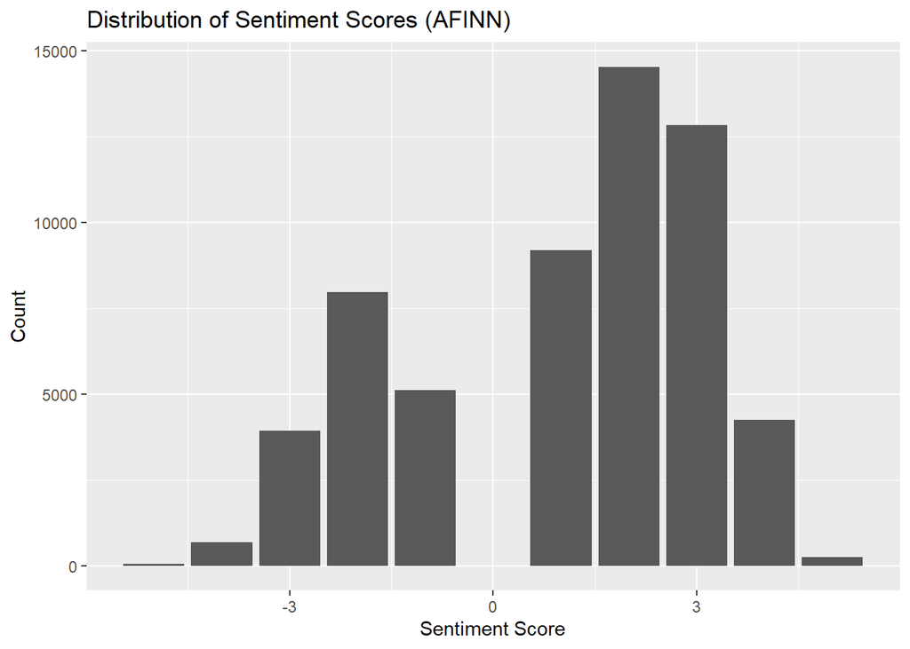

```r
ggplot(yelp_combined %>% filter(source == "afinn"), aes(x = value)) +
  geom_bar() +
  labs(title = "Distribution of Sentiment Scores (AFINN)", x = "Sentiment Score", y = "Count")
```

Emotional Categories ( NRC)

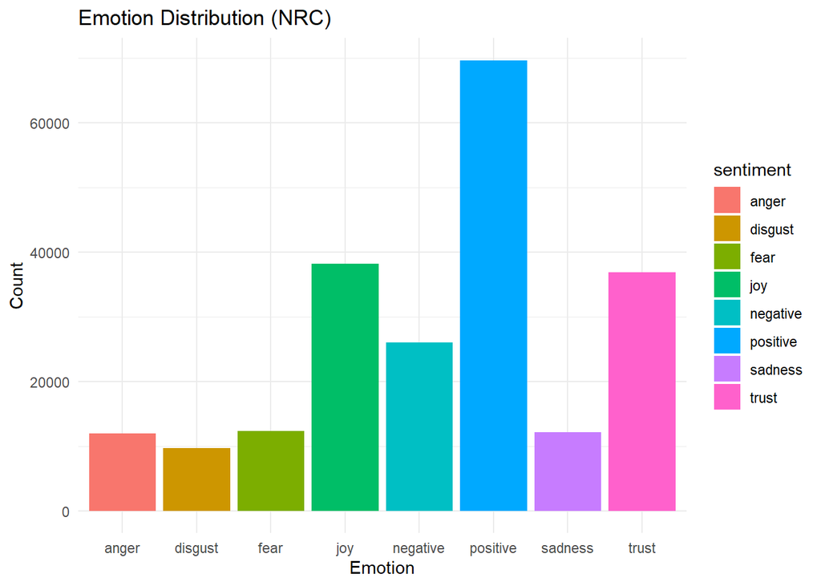

```r
nrc_summary <- yelp_combined %>%
  filter(source == "nrc") %>%
  group_by(sentiment) %>%
  summarise(count = n())

ggplot(nrc_summary, aes(x = sentiment, y = count, fill = sentiment)) +
  geom_bar(stat = "identity") +
  labs(title = "Emotion Distribution (NRC)", x = "Emotion", y = "Count") +
  theme_minimal()
```

## Normalizing the AFINN & NRC to match Bing

This chapter will normalize the values from AFINN and NRC lexicons to fall within Bing range of -1 to 1. This is necessary to be able to compare the 3 different lexicons together.Since Bing range is already -1 to 1 the focus is on AFINN and NRC

### Normalizing AFINN

```r
yelp_combined <- yelp_combined %>%
  mutate(
    afinn_normalized = ifelse(source == "afinn", value / 5, NA)
  )
```

### Normalizing NRC

With NRC lexicon, decision was made to add additional categories outside of positive and negative for higher covered value and also to be able to analyse more nuanced sentiments that exist in NRC. To normalize the NRC categories to be binary the decision was made to place sadness, anger, disgust and fear in negative (or assign it -1 value) while joy and trust were assigned +1 value. Due to ambiguity of the surprise category, the entire category was left out of further analysis.

```r
# Assign numerical values to all NRC categories
yelp_combined <- yelp_combined %>%
  mutate(
    nrc_score = case_when(
      source == "nrc" & sentiment %in% c("negative","sadness", "anger", "disgust", "fear") ~ -1,
      source == "nrc" & sentiment %in% c("positive","joy", "trust") ~ 1,
      TRUE ~ NA_real_  # Ignore neutral/ambiguous categories like "surprise"
    )
  )
```

### Combinig the lexicons

```r
yelp_aggregated <- yelp_combined %>%
  group_by(word, review_id) %>%
  summarise(
    afinn_score = mean(afinn_normalized, na.rm = TRUE),
    bing_score = mean(ifelse(source == "bing", ifelse(sentiment == "positive", 1, -1), NA), na.rm = TRUE),
    nrc_score = mean(nrc_score, na.rm = TRUE),
    aggregated_score = mean(c(afinn_normalized, ifelse(source == "bing", ifelse(sentiment == "positive", 1, -1), NA), nrc_score), na.rm = TRUE)
  ) %>%
  filter(!is.na(aggregated_score))  # Remove words with no aggregated score
```

### Visualizing Aggregated Sentiment

Distribution of aggregated scores

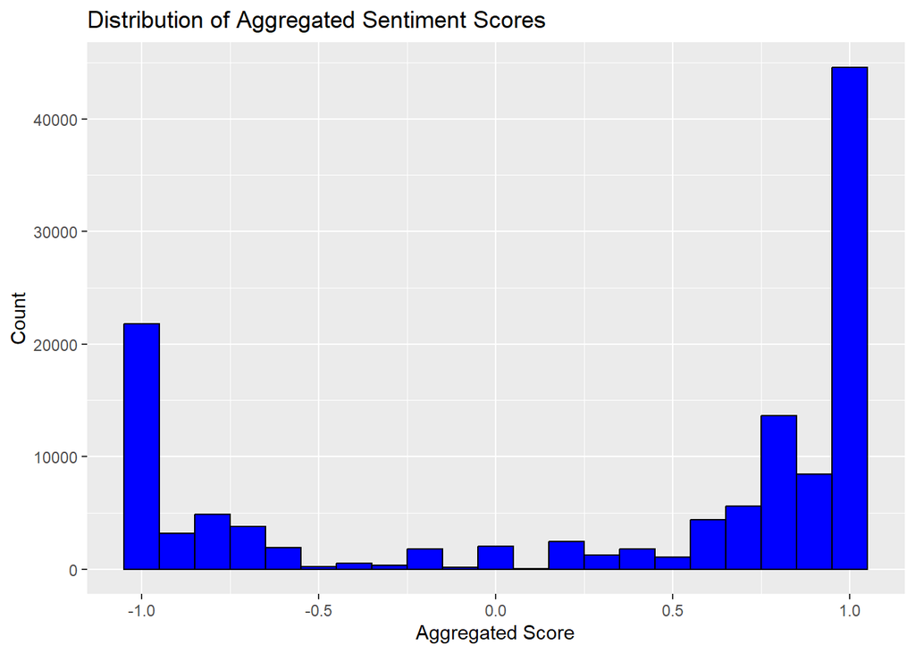

```r
ggplot(yelp_aggregated, aes(x = aggregated_score)) +
  geom_histogram(binwidth = 0.1, fill = "blue", color = "black") +
  labs(title = "Distribution of Aggregated Sentiment Scores", x = "Aggregated Score", y = "Count")
```

Top positive and negative words

```r
# Top positive words
top_positive <- yelp_aggregated %>%
  arrange(desc(aggregated_score)) %>%
  head(10)

# Top negative words
top_negative <- yelp_aggregated %>%
  arrange(aggregated_score) %>%
  head(10)

print(top_positive)
```

```
## # A tibble: 10 × 6
## # Groups:   word [4]
##    word     review_id          afinn_score bing_score nrc_score aggregated_score
##    <chr>    <chr>                    <dbl>      <dbl>     <dbl>            <dbl>
##  1 abacus   V-MMwDZ7GcxAsiIDq…         NaN        NaN         1                1
##  2 abba     b0NnnjzhDmI7feVNz…         NaN        NaN         1                1
##  3 abound   5R6wVDhn4wOiQAmKh…         NaN          1       NaN                1
##  4 abound   FRoQi0lZiE39b-XLm…         NaN          1       NaN                1
##  5 abound   INgYGonM78YMB-5vp…         NaN          1       NaN                1
##  6 absolute -9QqRlAKuR2oERQNp…         NaN        NaN         1                1
##  7 absolute -anI_3FEizR1wNUkX…         NaN        NaN         1                1
##  8 absolute 0CbilnyXmdtPc3-Hd…         NaN        NaN         1                1
##  9 absolute 1WupnSzzotzuhjkyl…         NaN        NaN         1                1
## 10 absolute 2SyBuAtRjEF8DMTzF…         NaN        NaN         1                1
```

```r
print(top_negative)
```

```
## # A tibble: 10 × 6
## # Groups:   word [6]
##    word       review_id        afinn_score bing_score nrc_score aggregated_score
##    <chr>      <chr>                  <dbl>      <dbl>     <dbl>            <dbl>
##  1 aberration swAgg95rDJ6I2SL…         NaN        NaN        -1               -1
##  2 abrasion   qEiGnUUGu6qr_LY…         NaN        NaN        -1               -1
##  3 abrasive   FHo3Zk0LJ6REZ4b…         NaN         -1       NaN               -1
##  4 abrupt     H54TDc1pXQIr4Oy…         NaN         -1       NaN               -1
##  5 abrupt     s6Gx6KvpjEdbNK_…         NaN         -1       NaN               -1
##  6 abrupt     vJStEy9x9YOwI9o…         NaN         -1       NaN               -1
##  7 abrupt     xcH0rhqObozrlZT…         NaN         -1       NaN               -1
##  8 abruptly   a0n3pnYyVb_7z_x…         NaN         -1       NaN               -1
##  9 absence    5p6ojcHIsFWKkNn…         NaN         -1        -1               -1
## 10 absence    M6f3hxIjgi8B4HQ…         NaN         -1        -1               -1
```

```r
yelp_aggregated_no_review_id <- yelp_aggregated %>%
  select(-review_id)

# Calculate overall aggregated score for each word
word_scores <- yelp_aggregated_no_review_id %>%
  group_by(word) %>%
  summarise(
    avg_aggregated_score = mean(aggregated_score, na.rm = TRUE),  # Average score across all occurrences
    num_occurrences = n()  # Count how often the word appears
  ) %>%
  filter(!is.na(avg_aggregated_score))  # Remove words with no valid scores

# Top positive words
top_positive <- word_scores %>%
  arrange(desc(num_occurrences)) %>%  # Sort by highest score
  head(30)

# Top negative words
top_negative <- word_scores %>%
  arrange(desc(avg_aggregated_score)) %>%  # Sort by lowest score
  head(10)

# Print results
print(top_positive)
```

```
## # A tibble: 30 × 3
##    word      avg_aggregated_score num_occurrences
##    <chr>                    <dbl>           <int>
##  1 food                     1                3932
##  2 nice                     0.8              1771
##  3 love                     0.860            1735
##  4 friendly                 0.798            1431
##  5 pretty                   0.721            1430
##  6 delicious                1                1149
##  7 chicken                 -1                1134
##  8 eat                      1                1018
##  9 fresh                    0.6               990
## 10 wait                    -1                 918
## # ℹ 20 more rows
```

```r
print(top_negative)
```

```
## # A tibble: 10 × 3
##    word       avg_aggregated_score num_occurrences
##    <chr>                     <dbl>           <int>
##  1 abacus                        1               1
##  2 abba                          1               1
##  3 abound                        1               3
##  4 absolute                      1              55
##  5 abundant                      1               4
##  6 academy                       1               2
##  7 acceptable                    1              25
##  8 accessible                    1              19
##  9 acclaimed                     1               2
## 10 accolades                     1               4
```

Emotional tone analysis

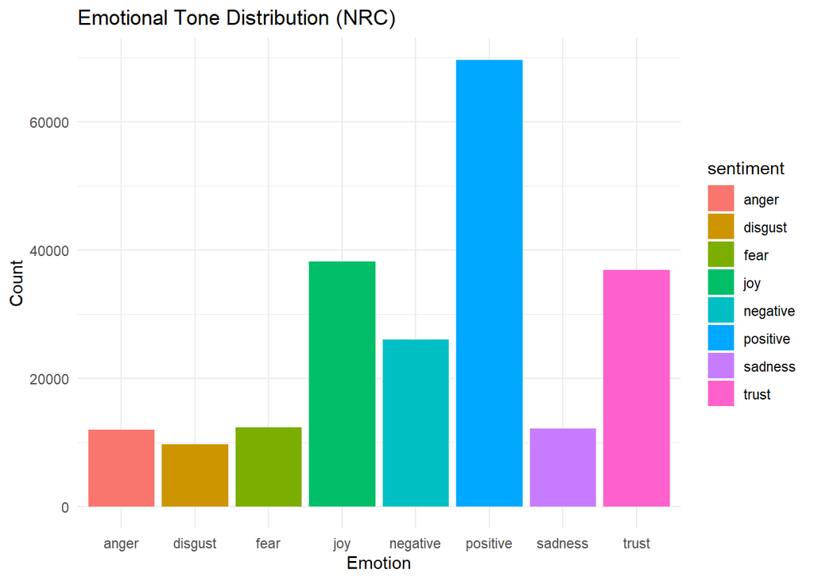

```r
emotional_tone <- yelp_combined %>%
  filter(source == "nrc") %>%
  group_by(sentiment) %>%
  summarise(count = n())

ggplot(emotional_tone, aes(x = sentiment, y = count, fill = sentiment)) +
  geom_bar(stat = "identity") +
  labs(title = "Emotional Tone Distribution (NRC)", x = "Emotion", y = "Count") +
  theme_minimal()
```

## Analizing sentiments by business_id

To analize sentiments by business_id we need column aggregated_score from yelp_aggregated data frame. We must first merge this data frame to yelp_combined

```r
# Merge aggregated_score from yelp_aggregated into yelp_combined
yelp_final <- yelp_combined %>%
  left_join(yelp_aggregated %>% select(word, review_id, aggregated_score), by = c("word", "review_id"))

# Inspect the merged dataframe
glimpse(yelp_final)
```

```
## Rows: 678,986
## Columns: 12
## $ review_id        <chr> "fWKvX83p0-ka4JS3dc6E5A", "fWKvX83p0-ka4JS3dc6E5A", "…
## $ user_id          <chr> "rLtl8ZkDX5vH5nAx9C3q5Q", "rLtl8ZkDX5vH5nAx9C3q5Q", "…
## $ date             <date> 2011-01-26, 2011-01-26, 2011-01-26, 2011-01-26, 2011…
## $ stars            <dbl> 5, 5, 5, 5, 5, 5, 5, 5, 5, 5, 5, 5, 5, 5, 5, 5, 5, 5,…
## $ business_id      <chr> "9yKzy9PApeiPPOUJEtnvkg", "9yKzy9PApeiPPOUJEtnvkg", "…
## $ word             <chr> "wife", "birthday", "birthday", "breakfast", "excelle…
## $ value            <dbl> NA, NA, NA, NA, 3, NA, NA, NA, NA, NA, 3, NA, NA, NA,…
## $ source           <chr> NA, "nrc", "nrc", "nrc", "afinn", "nrc", "nrc", "nrc"…
## $ sentiment        <chr> NA, "joy", "positive", "positive", "positive", "joy",…
## $ afinn_normalized <dbl> NA, NA, NA, NA, 0.6, NA, NA, NA, NA, NA, 0.6, NA, NA,…
## $ nrc_score        <dbl> NA, 1, 1, 1, NA, 1, 1, 1, NA, NA, NA, 1, 1, 1, NA, NA…
## $ aggregated_score <dbl> NA, 1.0000000, 1.0000000, 1.0000000, 0.8285714, 0.828…
```

### Visualizing aggregated sentiment scores per business_id

[figure not shown]

```r
# Aggregate sentiment by business_id
business_sentiment <- yelp_final %>%
  group_by(business_id) %>%
  summarise(
    avg_sentiment = mean(aggregated_score, na.rm = TRUE),
    num_reviews = n()
  ) %>%
  arrange(desc(avg_sentiment))  # Sort by average sentiment

# Visualize top and bottom businesses
top_businesses <- head(business_sentiment, 10)
bottom_businesses <- tail(business_sentiment, 10)

ggplot(business_sentiment, aes(x = reorder(business_id, avg_sentiment), y = avg_sentiment)) +
  geom_bar(stat = "identity", fill = "blue") +
  coord_flip() +
  labs(title = "Average Sentiment by Business", x = "Business ID", y = "Average Sentiment")
```

Finding the business_id with the most reviews:

```r
# Find the most frequent business_id
most_frequent_business <- yelp_final %>%
  group_by(business_id) %>%
  summarize(count = n()) %>%
  slice_max(count, n = 1)

# Print the result
print(most_frequent_business)
```

```
## # A tibble: 1 × 2
##   business_id            count
##   <chr>                  <int>
## 1 VVeogjZya58oiTxK7qUjAQ  3161
```

Previous code chunk counted all the words associated with the particular business_id. What was needed was the number of distinct review_id associated with the business_id. Following code will address this and also list top 10 business_id with the highest count of unique review_id’s:

```r
# Find top 10 business_ids with the highest count of unique review_ids
top_10_businesses <- yelp_final %>%
  group_by(business_id) %>%
  summarize(unique_review_count = n_distinct(review_id)) %>%  # Count unique review_ids
  arrange(desc(unique_review_count)) %>%                     # Sort by count (descending)
  slice_head(n = 10)                                         # Select top 10

# Print the result
print(top_10_businesses)
```

```
## # A tibble: 10 × 2
##    business_id            unique_review_count
##    <chr>                                <int>
##  1 JokKtdXU7zXHcr20Lrk29A                  37
##  2 ntN85eu27C04nwyPa8IHtw                  37
##  3 hW0Ne_HTHEAgGF1rAdmR-g                  34
##  4 WNy1uzcmm_UHmTyR--o5IA                  32
##  5 VVeogjZya58oiTxK7qUjAQ                  31
##  6 V1nEpIRmEa1768oj_tuxeQ                  30
##  7 SDwYQ6eSu1htn8vHWv128g                  25
##  8 uKSX1n1RoAzGq4bV8GPHVg                  25
##  9 -sC66z4SO3tR7nFCjfQwuQ                  24
## 10 EWMwV5V9BxNs_U6nNVMeqw                  24
```

Identifying top businesses:

```r
# Identify top businesses by review count
top_businesses <- yelp_final %>%
  group_by(business_id) %>%
  summarise(
    num_reviews = n_distinct(review_id),  # Count unique reviews per business
    avg_sentiment = mean(aggregated_score, na.rm = TRUE)
  ) %>%
  arrange(desc(num_reviews)) %>%  # Sort by review count
  head(25)  # Select top 25 businesses

# View the top businesses
print(top_businesses)
```

```
## # A tibble: 25 × 3
##    business_id            num_reviews avg_sentiment
##    <chr>                        <int>         <dbl>
##  1 JokKtdXU7zXHcr20Lrk29A          37        0.438
##  2 ntN85eu27C04nwyPa8IHtw          37        0.229
##  3 hW0Ne_HTHEAgGF1rAdmR-g          34        0.0388
##  4 WNy1uzcmm_UHmTyR--o5IA          32        0.369
##  5 VVeogjZya58oiTxK7qUjAQ          31        0.295
##  6 V1nEpIRmEa1768oj_tuxeQ          30        0.386
##  7 SDwYQ6eSu1htn8vHWv128g          25        0.373
##  8 uKSX1n1RoAzGq4bV8GPHVg          25        0.296
##  9 -sC66z4SO3tR7nFCjfQwuQ          24        0.294
## 10 EWMwV5V9BxNs_U6nNVMeqw          24        0.390
## # ℹ 15 more rows
```

Visualizing top 25 businesses

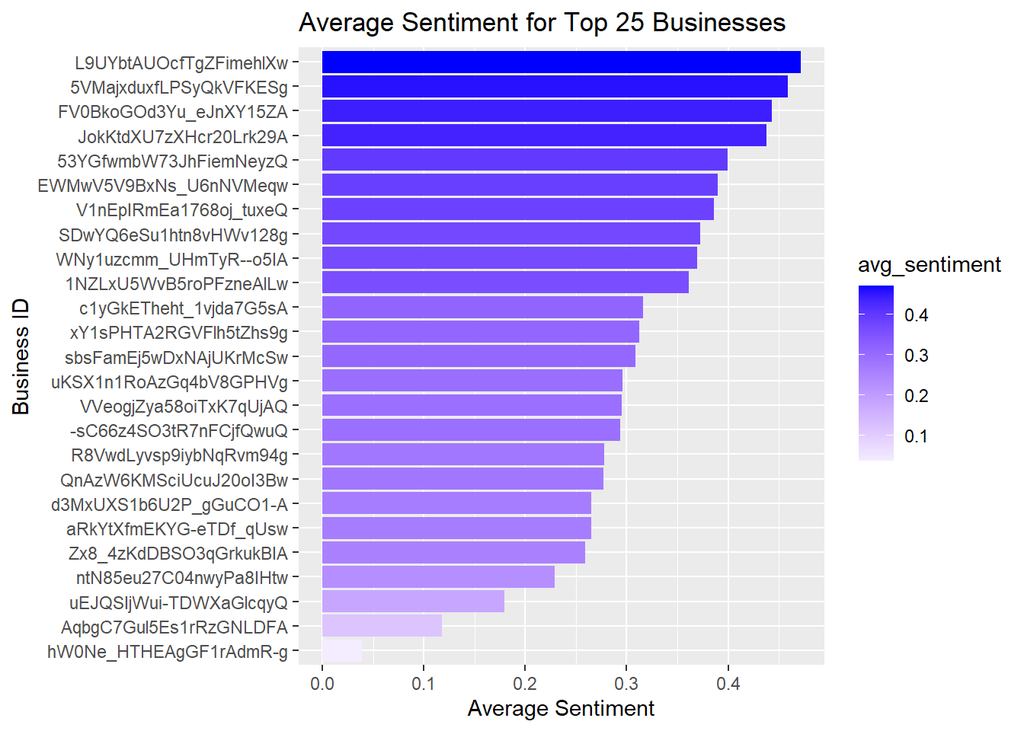

```r
# Visualize sentiment for top businesses
ggplot(top_businesses, aes(x = reorder(business_id, avg_sentiment), y = avg_sentiment, fill = avg_sentiment)) +
  geom_bar(stat = "identity") +
  coord_flip() +
  scale_fill_gradient2(low = "red", mid = "white", high = "blue", midpoint = 0) +
  labs(title = "Average Sentiment for Top 25 Businesses", x = "Business ID", y = "Average Sentiment")
```

## Filtering Specific business_id

The account with the highest count of unique review_id’s was used since it had a relatively high aggregated score, 0.43 where highest aggregated score was 0.44 but unique review_ids was significantly less (22 compared to 37). So the business ID with 37 unique review_id and score of 0.43 was selected over the business_id with highest aggregated score.

```r
# Filter data for a specific business (e.g., top_business_id)
top_business_id <- "JokKtdXU7zXHcr20Lrk29A"
business_reviews <- yelp_final %>%
  filter(business_id == top_business_id)

# Inspect the filtered data
glimpse(business_reviews)
```

```
## Rows: 2,413
## Columns: 12
## $ review_id        <chr> "wxJbkvhNEu0O9ghfFPE8nw", "wxJbkvhNEu0O9ghfFPE8nw", "…
## $ user_id          <chr> "BgY9LwHmY8BO_lPI3pNRFQ", "BgY9LwHmY8BO_lPI3pNRFQ", "…
## $ date             <date> 2011-01-29, 2011-01-29, 2011-01-29, 2011-01-29, 2011…
## $ stars            <dbl> 4, 4, 4, 4, 4, 4, 4, 4, 4, 4, 4, 4, 4, 4, 4, 4, 4, 4,…
## $ business_id      <chr> "JokKtdXU7zXHcr20Lrk29A", "JokKtdXU7zXHcr20Lrk29A", "…
## $ word             <chr> "fan", "food", "food", "food", "beer", "beer", "memor…
## $ value            <dbl> 3, NA, NA, NA, NA, NA, NA, NA, NA, NA, NA, 4, NA, NA,…
## $ source           <chr> "afinn", "nrc", "nrc", "nrc", "nrc", "nrc", NA, "nrc"…
## $ sentiment        <chr> "positive", "joy", "positive", "trust", "joy", "posit…
## $ afinn_normalized <dbl> 0.6, NA, NA, NA, NA, NA, NA, NA, NA, NA, NA, 0.8, NA,…
## $ nrc_score        <dbl> NA, 1, 1, 1, 1, 1, NA, -1, NA, NA, 1, NA, NA, -1, -1,…
## $ aggregated_score <dbl> 0.6000000, 1.0000000, 1.0000000, 1.0000000, 1.0000000…
```

Sentiment of business over time

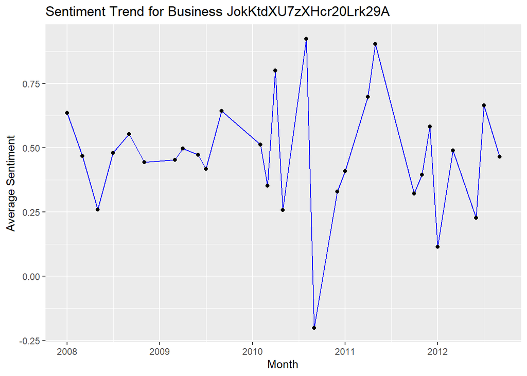

```r
# Aggregate sentiment by month
monthly_sentiment <- business_reviews %>%
  mutate(month = floor_date(date, "month")) %>%  # Group by month
  group_by(month) %>%
  summarise(
    avg_sentiment = mean(aggregated_score, na.rm = TRUE),  # Average sentiment
    num_reviews = n()  # Number of reviews per month
  )

# Visualize sentiment trend over time
ggplot(monthly_sentiment, aes(x = month, y = avg_sentiment)) +
  geom_line(color = "blue") +
  geom_point() +
  labs(title = paste("Sentiment Trend for Business", top_business_id),
       x = "Month",
       y = "Average Sentiment")
```

There is an obvious dip in the average sentiment in 3rd quarter of 2010. Lets dive deeper to see whats that about

```r
# Define the date range of interest
start_date <- as.Date("2010-06-01")
end_date <- as.Date("2010-09-30")

# Filter reviews for the specific business and time period
business_reviews_filtered <- yelp_final %>%
  filter(business_id == "JokKtdXU7zXHcr20Lrk29A" &
         date >= start_date &
         date <= end_date)

# Inspect the filtered data
glimpse(business_reviews_filtered)
```

```
## Rows: 50
## Columns: 12
## $ review_id        <chr> "XdAtb3hIzydAmzdFy0Ubyw", "XdAtb3hIzydAmzdFy0Ubyw", "…
## $ user_id          <chr> "TL46g36OKxmgSDYRFJdPRg", "TL46g36OKxmgSDYRFJdPRg", "…
## $ date             <date> 2010-08-05, 2010-08-05, 2010-08-05, 2010-08-05, 2010…
## $ stars            <dbl> 5, 5, 5, 5, 5, 5, 5, 5, 5, 5, 5, 5, 5, 5, 5, 5, 5, 5,…
## $ business_id      <chr> "JokKtdXU7zXHcr20Lrk29A", "JokKtdXU7zXHcr20Lrk29A", "…
## $ word             <chr> "solid", "solid", "solid", "delicious", "delicious", …
## $ value            <dbl> 2, NA, NA, NA, NA, NA, 3, NA, NA, NA, NA, NA, NA, NA,…
## $ source           <chr> "afinn", "nrc", "bing", "nrc", "nrc", "bing", "afinn"…
## $ sentiment        <chr> "positive", "positive", "positive", "joy", "positive"…
## $ afinn_normalized <dbl> 0.4, NA, NA, NA, NA, NA, 0.6, NA, NA, NA, NA, NA, NA,…
## $ nrc_score        <dbl> NA, 1, NA, 1, 1, NA, NA, 1, 1, NA, NA, NA, NA, NA, NA…
## $ aggregated_score <dbl> 0.8000000, 0.8000000, 0.8000000, 1.0000000, 1.0000000…
```

Visualizing weekly sentiment trend

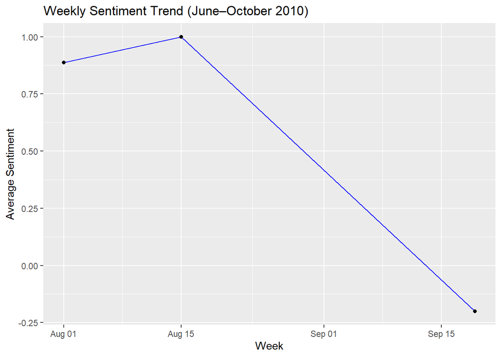

```r
# Aggregate sentiment by week
weekly_sentiment <- business_reviews_filtered %>%
  mutate(week = floor_date(date, "week")) %>%  # Group by week
  group_by(week) %>%
  summarise(
    avg_sentiment = mean(aggregated_score, na.rm = TRUE),
    num_reviews = n()
  )

# Visualize weekly sentiment trend
ggplot(weekly_sentiment, aes(x = week, y = avg_sentiment)) +
  geom_line(color = "blue") +
  geom_point() +
  labs(title = "Weekly Sentiment Trend (June–October 2010)",
       x = "Week",
       y = "Average Sentiment")
```

daily sentiment trend

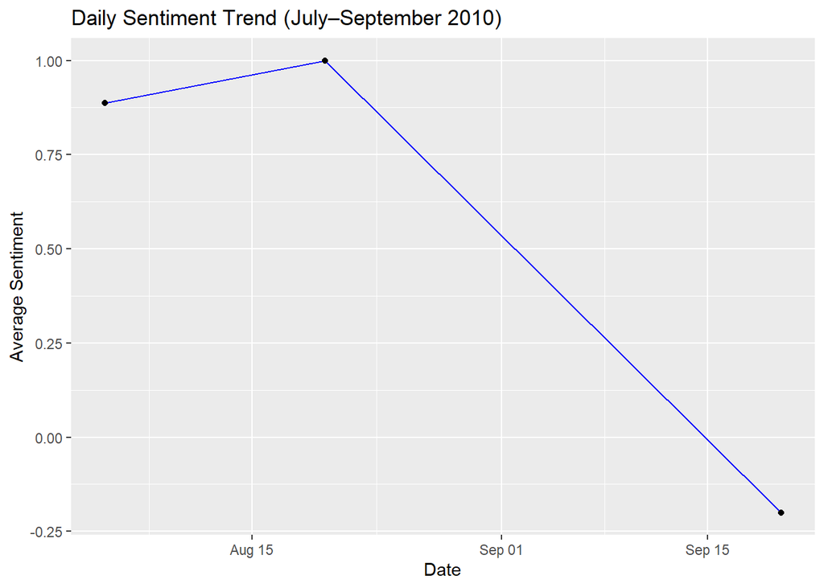

```r
# Aggregate sentiment by day
daily_sentiment <- business_reviews_filtered %>%
  group_by(date) %>%
  summarise(
    avg_sentiment = mean(aggregated_score, na.rm = TRUE),
    num_reviews = n()
  )

# Visualize daily sentiment trend
ggplot(daily_sentiment, aes(x = date, y = avg_sentiment)) +
  geom_line(color = "blue") +
  geom_point() +
  labs(title = "Daily Sentiment Trend (July–September 2010)",
       x = "Date",
       y = "Average Sentiment")
```

How many uniqure review_id is this time period?

```r
# Count the number of reviews in the filtered dataset
review_count <- business_reviews_filtered %>%
  summarise(num_reviews = n_distinct(review_id))

print(review_count)
```

```
## # A tibble: 1 × 1
##   num_reviews
##         <int>
## 1           3
```

Common themes during sentiment drop:

```r
# Identify the most frequent words during the time period
frequent_words <- business_reviews_filtered %>%
  count(word, sort = TRUE) %>%
  head(20)  # Top 20 words

# Print the most frequent words
print(frequent_words)
```

```
## # A tibble: 20 × 2
##    word           n
##    <chr>      <int>
##  1 beer           4
##  2 love           4
##  3 missing        4
##  4 delicious      3
##  5 difficult      3
##  6 solid          3
##  7 child          2
##  8 specials       2
##  9 admit          1
## 10 az             1
## 11 babysitter     1
## 12 brewery        1
## 13 changing       1
## 14 day            1
## 15 deschutes      1
## 16 didnt          1
## 17 dine           1
## 18 dont           1
## 19 drink          1
## 20 eat            1
```

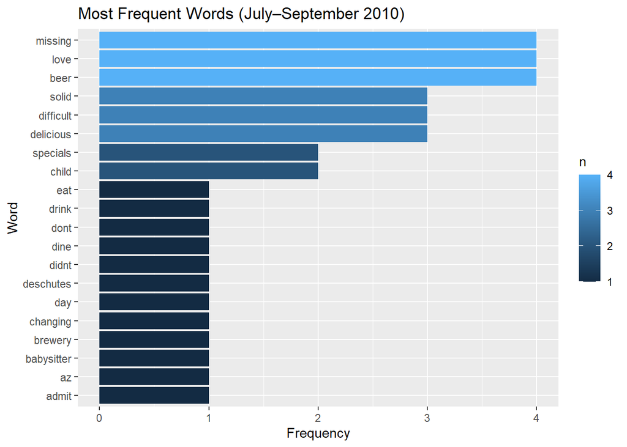

```r
# Visualize the most frequent words
ggplot(frequent_words, aes(x = reorder(word, n), y = n, fill = n)) +
  geom_bar(stat = "identity") +
  coord_flip() +
  labs(title = "Most Frequent Words (July–September 2010)",
       x = "Word",
       y = "Frequency")
```

Focus only on negative words during the same time:

```r
# Identify frequent negative words
negative_words <- business_reviews_filtered %>%
  filter(sentiment == "negative") %>%
  count(word, sort = TRUE) %>%
  head(20)

# Print the most frequent negative words
print(negative_words)
```

```
## # A tibble: 3 × 2
##   word          n
##   <chr>     <int>
## 1 difficult     2
## 2 missing       2
## 3 admit         1
```

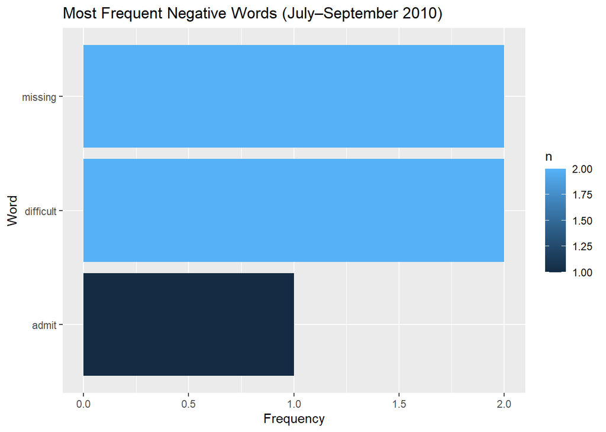

```r
# Visualize the most frequent negative words
ggplot(negative_words, aes(x = reorder(word, n), y = n, fill = n)) +
  geom_bar(stat = "identity") +
  coord_flip() +
  labs(title = "Most Frequent Negative Words (July–September 2010)",
       x = "Word",
       y = "Frequency")
```

lets do emotional tone during this time period

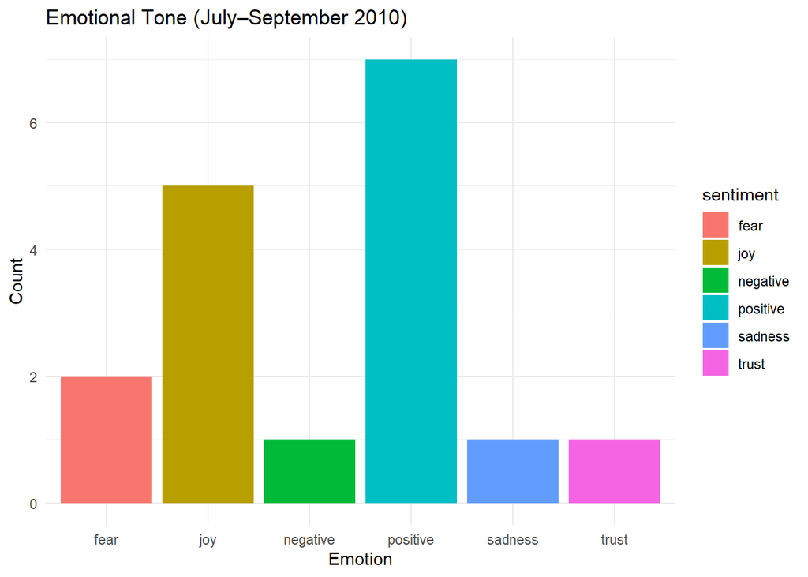

```r
# Analyze emotional tone for the time period
emotional_tone <- business_reviews_filtered %>%
  filter(source == "nrc") %>%
  group_by(sentiment) %>%
  summarise(count = n())

# Visualize emotional tone
ggplot(emotional_tone, aes(x = sentiment, y = count, fill = sentiment)) +
  geom_bar(stat = "identity") +
  labs(title = "Emotional Tone (July–September 2010)",
       x = "Emotion",
       y = "Count") +
  theme_minimal()
```

Common themes in reviews

```r
# Identify the most frequent words for the business
frequent_words <- business_reviews %>%
  count(word, sort = TRUE) %>%
  head(20)  # Top 20 words

# Print the most frequent words
print(frequent_words)
```

```
## # A tibble: 20 × 2
##    word          n
##    <chr>     <int>
##  1 food        141
##  2 beer        130
##  3 happy        80
##  4 love         44
##  5 pretty       30
##  6 peaks        27
##  7 excellent    25
##  8 fun          24
##  9 awesome      22
## 10 bad          21
## 11 favorite     20
## 12 friendly     20
## 13 perfect      20
## 14 beers        18
## 15 wrong        18
## 16 battered     16
## 17 day          16
## 18 fantastic    16
## 19 time         15
## 20 bar          13
```

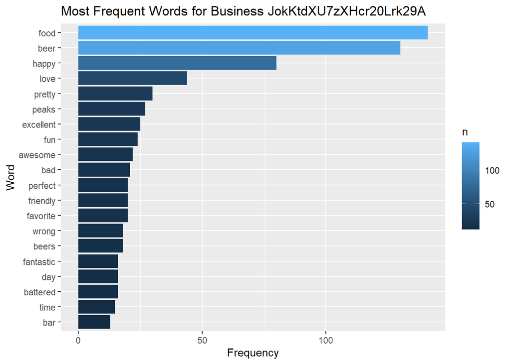

```r
# Visualize the most frequent words
ggplot(frequent_words, aes(x = reorder(word, n), y = n, fill = n)) +
  geom_bar(stat = "identity") +
  coord_flip() +
  labs(title = paste("Most Frequent Words for Business", top_business_id),
       x = "Word",
       y = "Frequency")
```

Emotional tone of the of reviews for top business

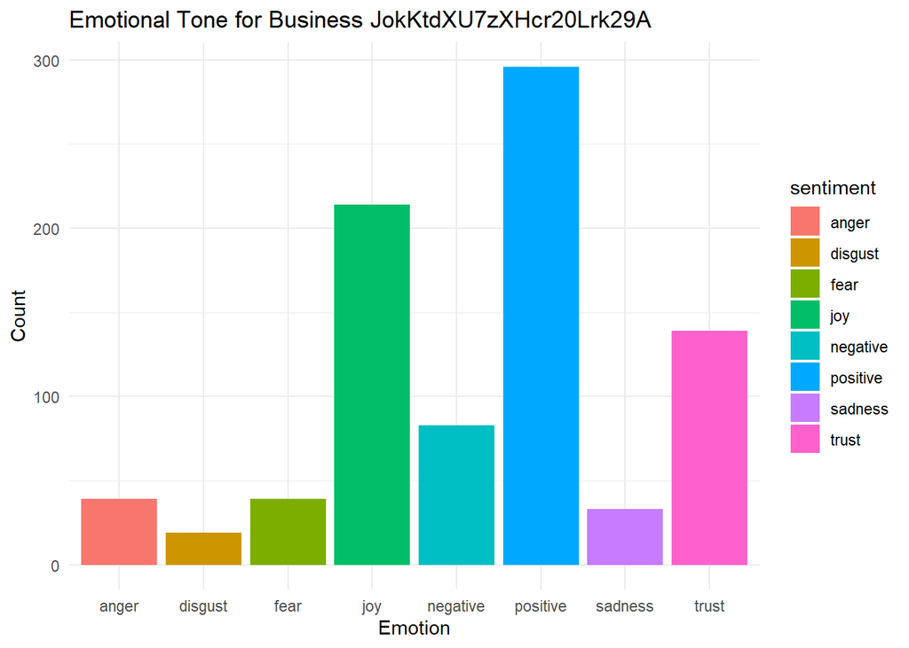

```r
# Analyze emotional tone for the business
emotional_tone <- business_reviews %>%
  filter(source == "nrc") %>%
  group_by(sentiment) %>%
  summarise(count = n())

# Visualize emotional tone
ggplot(emotional_tone, aes(x = sentiment, y = count, fill = sentiment)) +
  geom_bar(stat = "identity") +
  labs(title = paste("Emotional Tone for Business", top_business_id),
       x = "Emotion",
       y = "Count") +
  theme_minimal()
```

## Analysis of review_id

Code that calculates total sentiment per review

```r
# Calculate total sentiment for each review_id
review_sentiment <- yelp_final %>%
  group_by(review_id) %>%
  summarise(
    total_sentiment = sum(aggregated_score, na.rm = TRUE),  # Sum of sentiment scores
    num_words = n()  # Count of words in the review (optional)
  )

# Inspect the results
glimpse(review_sentiment)
```

```
## Rows: 9,994
## Columns: 3
## $ review_id       <chr> "--8hpKO4bkweLyEucdxI_w", "--DazeDpOApabZnIOIPSrQ", "-…
## $ total_sentiment <dbl> 25.160000, 12.533333, 17.066667, -3.200000, 17.666667,…
## $ num_words       <int> 55, 107, 68, 7, 35, 374, 24, 28, 87, 8, 31, 57, 75, 32…
```

```r
# View top reviews with highest and lowest sentiment
top_reviews <- review_sentiment %>%
  arrange(desc(total_sentiment)) %>%
  head(10)

bottom_reviews <- review_sentiment %>%
  arrange(total_sentiment) %>%
  head(10)

print(top_reviews)
```

```
## # A tibble: 10 × 3
##    review_id              total_sentiment num_words
##    <chr>                            <dbl>     <int>
##  1 cnFSJ52zVRmXT3JcrOmdUw           125.        379
##  2 qSEMTr86RSjlOsedZhXb_g           107.        404
##  3 IlHZnUkUGWQk3j0vYcMydg           107.        345
##  4 EJi2hMav9tkYMnP4JrelUA           104.        519
##  5 Qk5lp15fIkZoWVPnY4e0eA           102.        446
##  6 qaNZyCUJA6Yp0mvPBCknPQ           101.        327
##  7 dcWNhMfe67XhUPeeBTzJFQ            94.8       378
##  8 4gZStn31t8tz2Qva_oa3Zg            93.2       243
##  9 VhzdYHz3SWs-jjGnWQLYmQ            91.1       390
## 10 nW0bT4oCSeFdfJggs9cqVQ            89.1       241
```

```r
print(bottom_reviews)
```

```
## # A tibble: 10 × 3
##    review_id              total_sentiment num_words
##    <chr>                            <dbl>     <int>
##  1 nw66R5FsB3xjOVwyiymQog           -71.5       223
##  2 WRBYytJAaJI1BTQG5VI8oQ           -63.5       218
##  3 tjopNJVCRg6xlKXn9YapbQ           -48.9       171
##  4 nDMBoH-RR-dwTetO6ZW3qw           -45         279
##  5 I_1CgHj93GhRcOsWTwsm5A           -44.5       261
##  6 gKUsZQEEz9iqMpSQZNik_w           -44.0       202
##  7 SJroKRys5G5DV1uQz-W5LA           -43.1       109
##  8 aJuQa0UzELo3TfyySzaafQ           -42.4       218
##  9 5KTv4675TzICY5Y5cQoZgw           -41.8       185
## 10 6DOPdFlis83p8FRx64QIiQ           -39.9       280
```

Normalizing the sentiment scores

```r
# Normalize sentiment by dividing by the number of words
review_sentiment <- review_sentiment %>%
  mutate(
    avg_sentiment = total_sentiment / num_words
  )

# Inspect normalized sentiment
glimpse(review_sentiment)
```

```
## Rows: 9,994
## Columns: 4
## $ review_id       <chr> "--8hpKO4bkweLyEucdxI_w", "--DazeDpOApabZnIOIPSrQ", "-…
## $ total_sentiment <dbl> 25.160000, 12.533333, 17.066667, -3.200000, 17.666667,…
## $ num_words       <int> 55, 107, 68, 7, 35, 374, 24, 28, 87, 8, 31, 57, 75, 32…
## $ avg_sentiment   <dbl> 0.45745455, 0.11713396, 0.25098039, -0.45714286, 0.504…
```

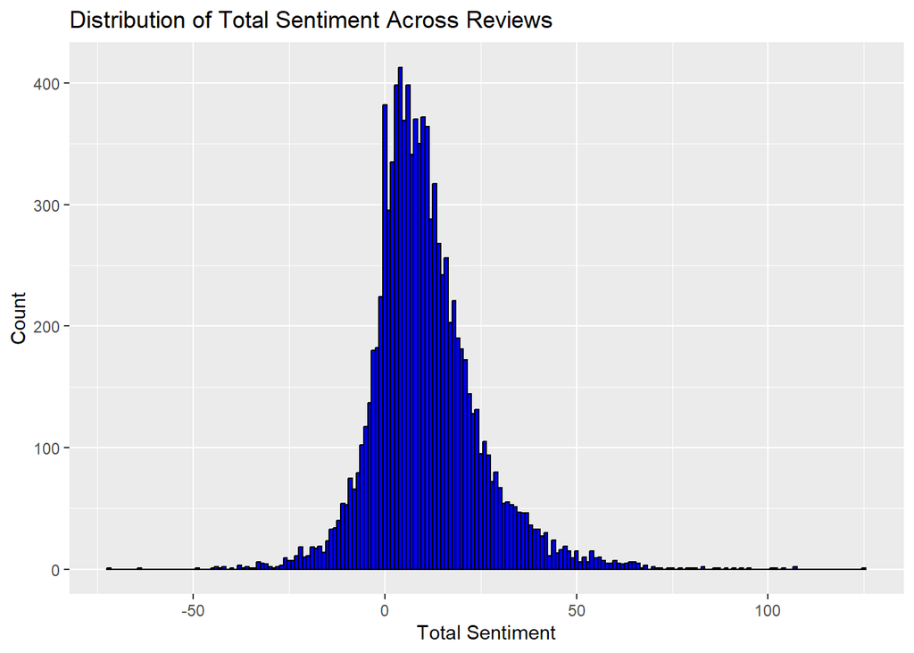

```r
# Histogram of total sentiment
ggplot(review_sentiment, aes(x = total_sentiment)) +
  geom_histogram(binwidth = 1, fill = "blue", color = "black") +
  labs(title = "Distribution of Total Sentiment Across Reviews", x = "Total Sentiment", y = "Count")
```

Sentiment over time

total sentiment column must first be added to the yelp final

```r
# Merge total_sentiment back into yelp_final
yelp_final <- yelp_final %>%
  left_join(review_sentiment %>% select(review_id, total_sentiment), by = "review_id")

# Inspect the updated dataframe
glimpse(yelp_final)
```

```
## Rows: 678,986
## Columns: 13
## $ review_id        <chr> "fWKvX83p0-ka4JS3dc6E5A", "fWKvX83p0-ka4JS3dc6E5A", "…
## $ user_id          <chr> "rLtl8ZkDX5vH5nAx9C3q5Q", "rLtl8ZkDX5vH5nAx9C3q5Q", "…
## $ date             <date> 2011-01-26, 2011-01-26, 2011-01-26, 2011-01-26, 2011…
## $ stars            <dbl> 5, 5, 5, 5, 5, 5, 5, 5, 5, 5, 5, 5, 5, 5, 5, 5, 5, 5,…
## $ business_id      <chr> "9yKzy9PApeiPPOUJEtnvkg", "9yKzy9PApeiPPOUJEtnvkg", "…
## $ word             <chr> "wife", "birthday", "birthday", "breakfast", "excelle…
## $ value            <dbl> NA, NA, NA, NA, 3, NA, NA, NA, NA, NA, 3, NA, NA, NA,…
## $ source           <chr> NA, "nrc", "nrc", "nrc", "afinn", "nrc", "nrc", "nrc"…
## $ sentiment        <chr> NA, "joy", "positive", "positive", "positive", "joy",…
## $ afinn_normalized <dbl> NA, NA, NA, NA, 0.6, NA, NA, NA, NA, NA, 0.6, NA, NA,…
## $ nrc_score        <dbl> NA, 1, 1, 1, NA, 1, 1, 1, NA, NA, NA, 1, 1, 1, NA, NA…
## $ aggregated_score <dbl> NA, 1.0000000, 1.0000000, 1.0000000, 0.8285714, 0.828…
## $ total_sentiment  <dbl> 39.29524, 39.29524, 39.29524, 39.29524, 39.29524, 39.…
```

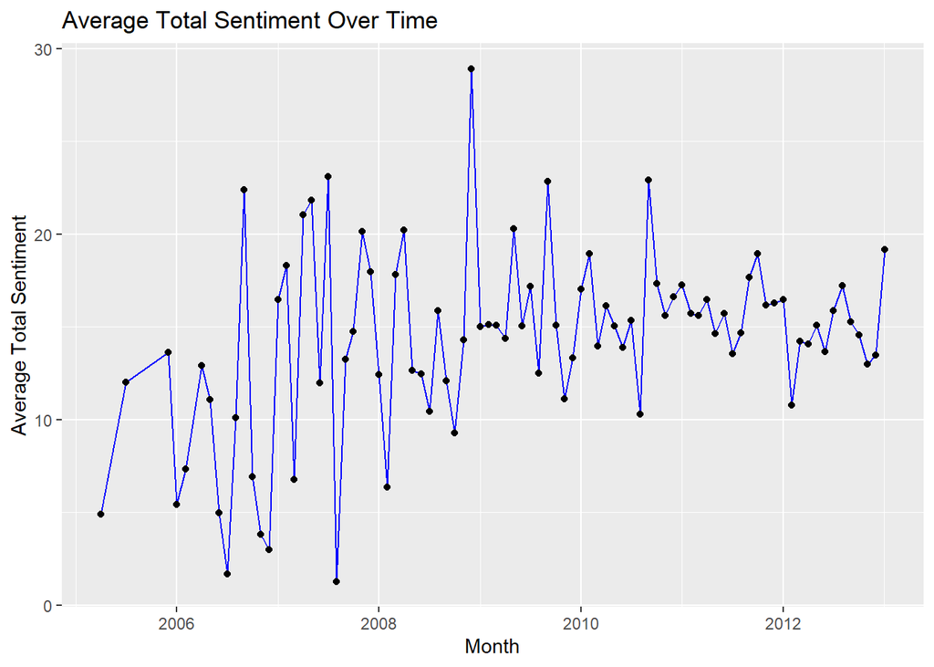

```r
# Aggregate sentiment by month
monthly_sentiment <- yelp_final %>%
  mutate(month = floor_date(date, "month")) %>%
  group_by(month) %>%
  summarise(
    avg_total_sentiment = mean(total_sentiment, na.rm = TRUE),
    num_reviews = n_distinct(review_id)
  )

# Visualize sentiment trend
ggplot(monthly_sentiment, aes(x = month, y = avg_total_sentiment)) +
  geom_line(color = "blue") +
  geom_point() +
  labs(title = "Average Total Sentiment Over Time", x = "Month", y = "Average Total Sentiment")
```

### preparing the data for visualization of word count vs sentiment score

```r
# Calculate total sentiment and word count for each review
review_sentiment <- yelp_final %>%
  group_by(review_id) %>%
  summarise(
    total_sentiment = sum(aggregated_score, na.rm = TRUE),  # Sum of sentiment scores
    num_words = n()                                         # Count of words in the review
  )

# Inspect the results
glimpse(review_sentiment)
```

```
## Rows: 9,994
## Columns: 3
## $ review_id       <chr> "--8hpKO4bkweLyEucdxI_w", "--DazeDpOApabZnIOIPSrQ", "-…
## $ total_sentiment <dbl> 25.160000, 12.533333, 17.066667, -3.200000, 17.666667,…
## $ num_words       <int> 55, 107, 68, 7, 35, 374, 24, 28, 87, 8, 31, 57, 75, 32…
```

#### scetter plot

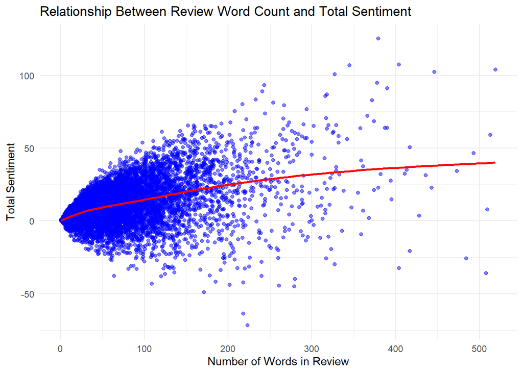

```r
# Scatter plot of word count vs. total sentiment
ggplot(review_sentiment, aes(x = num_words, y = total_sentiment)) +
  geom_point(alpha = 0.5, color = "blue") +  # Add transparency for overlapping points
  geom_smooth(method = "loess", se = FALSE, color = "red") +  # Add a trend line
  labs(
    title = "Relationship Between Review Word Count and Total Sentiment",
    x = "Number of Words in Review",
    y = "Total Sentiment"
  ) +
  theme_minimal()
```

Mild positive relationship where more words per review leads to generally higher sentiment score.

#### Boxplot

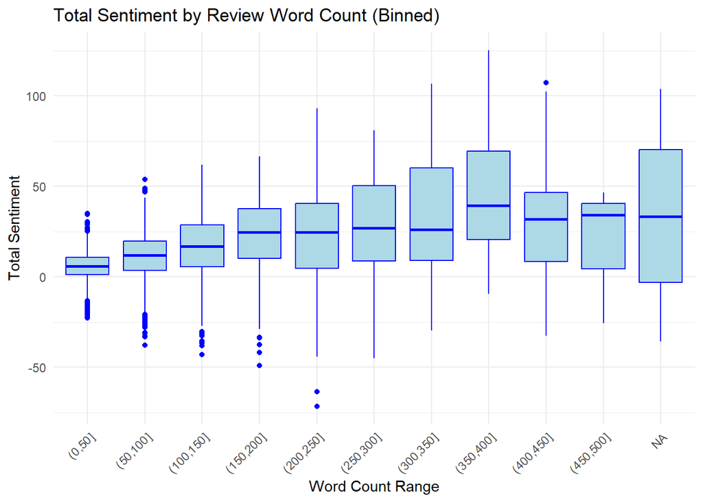

```r
# Create bins for word count
review_sentiment <- review_sentiment %>%
  mutate(word_count_bin = cut(num_words, breaks = seq(0, max(num_words, na.rm = TRUE), by = 50)))

# Boxplot of total sentiment by word count bins
ggplot(review_sentiment, aes(x = word_count_bin, y = total_sentiment)) +
  geom_boxplot(fill = "lightblue", color = "blue") +
  labs(
    title = "Total Sentiment by Review Word Count (Binned)",
    x = "Word Count Range",
    y = "Total Sentiment"
  ) +
  theme_minimal() +
  theme(axis.text.x = element_text(angle = 45, hjust = 1))  # Rotate x-axis labels for readability
```

Similar trend is noticed, we just now can see better that the variation i the sentiment is greater as the word count grows. It was noticable in scatter plot as well but here visualization is cleaner.

#### Density plot

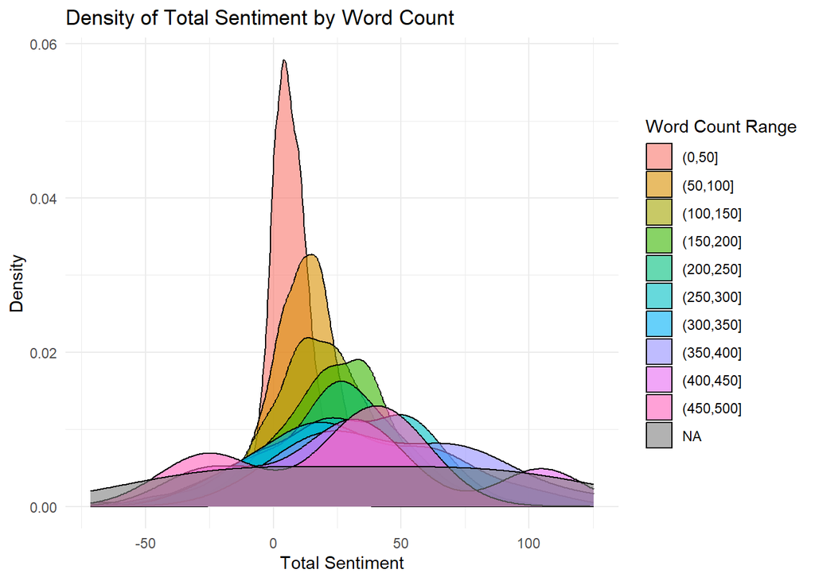

```r
# Density plot of total sentiment colored by word count
ggplot(review_sentiment, aes(x = total_sentiment, fill = cut(num_words, breaks = seq(0, max(num_words, na.rm = TRUE), by = 50)))) +
  geom_density(alpha = 0.6) +
  labs(
    title = "Density of Total Sentiment by Word Count",
    x = "Total Sentiment",
    y = "Density",
    fill = "Word Count Range"
  ) +
  theme_minimal()
```